# Homework 3

Irem Ozturk

## Data Visualization

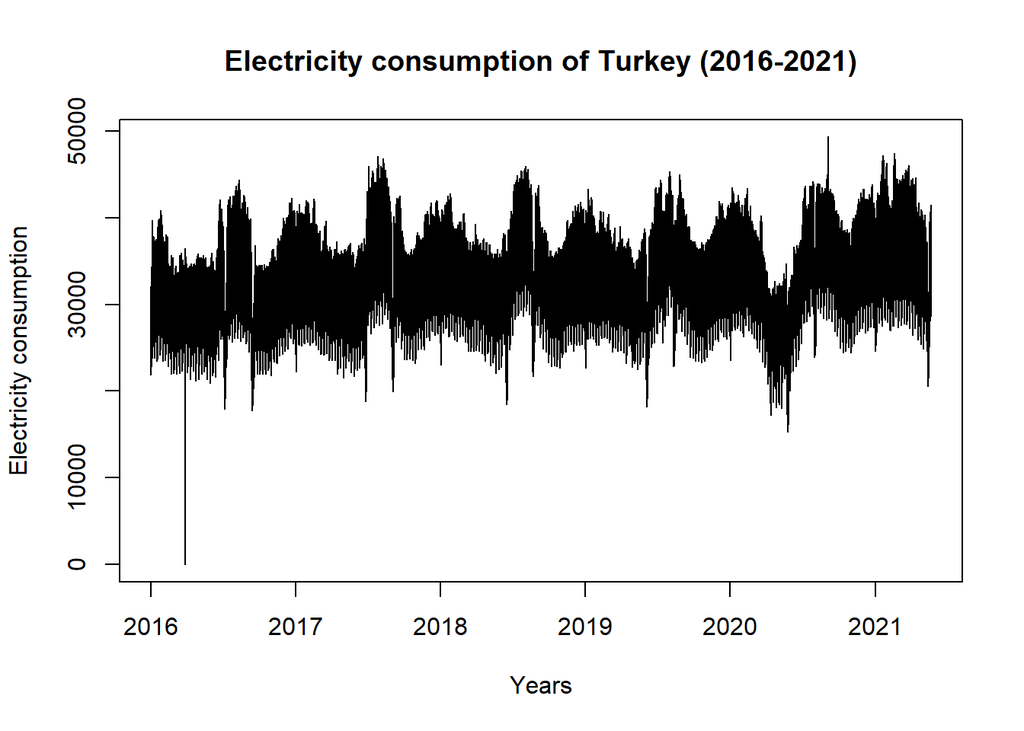

## Seasonality

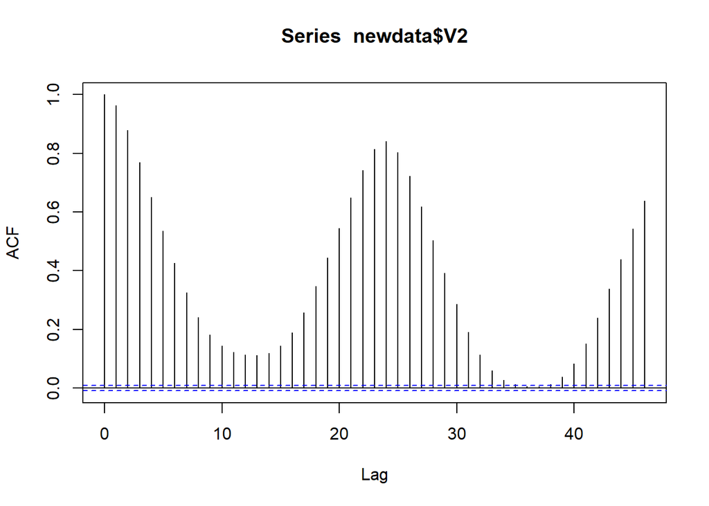

Apart from the autocorrelation at lag 1, there is a significant autocorrelation at lag 24, so we can say that there is daily seasonality. When turning our data into time series I’ll use frequency as 24.

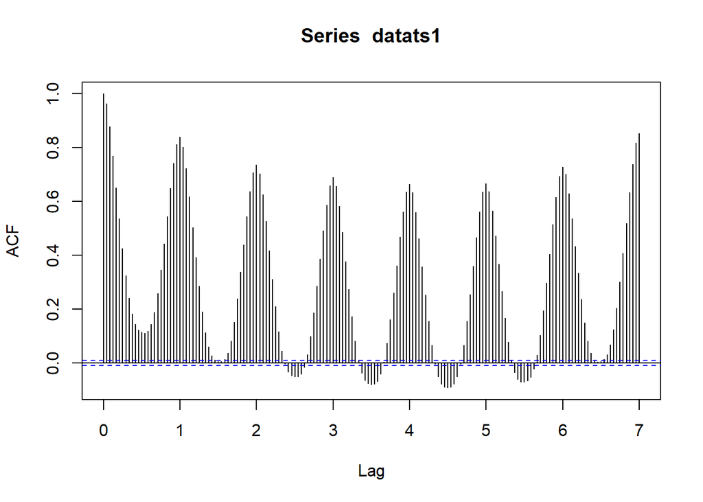

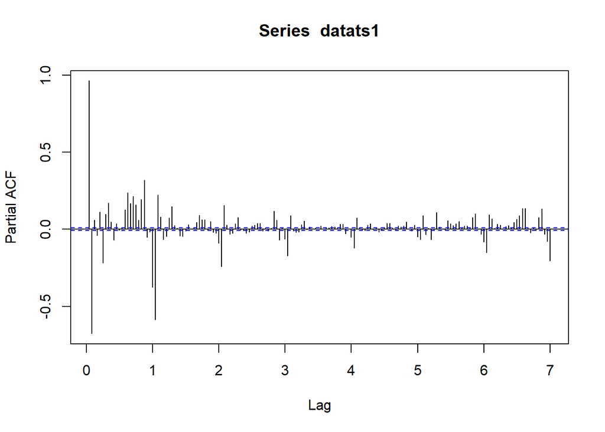

There is a significant autocorrelation at lag 7 compared to others. This means that weekly seasonality may occur. Also we will look at the monthly seasonality.

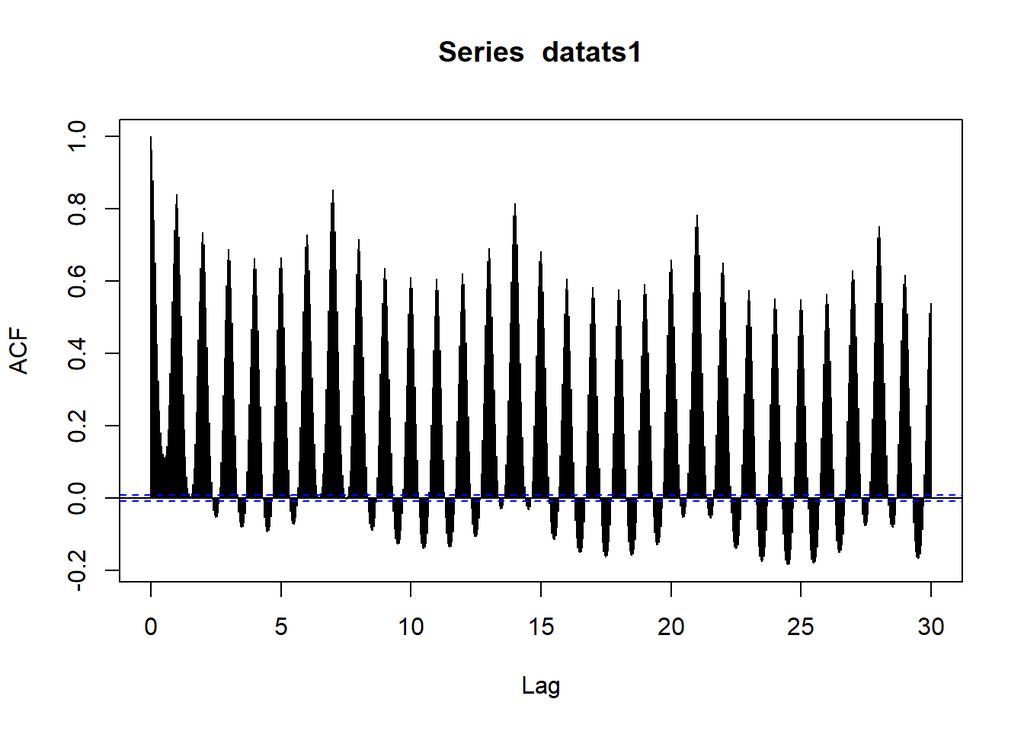

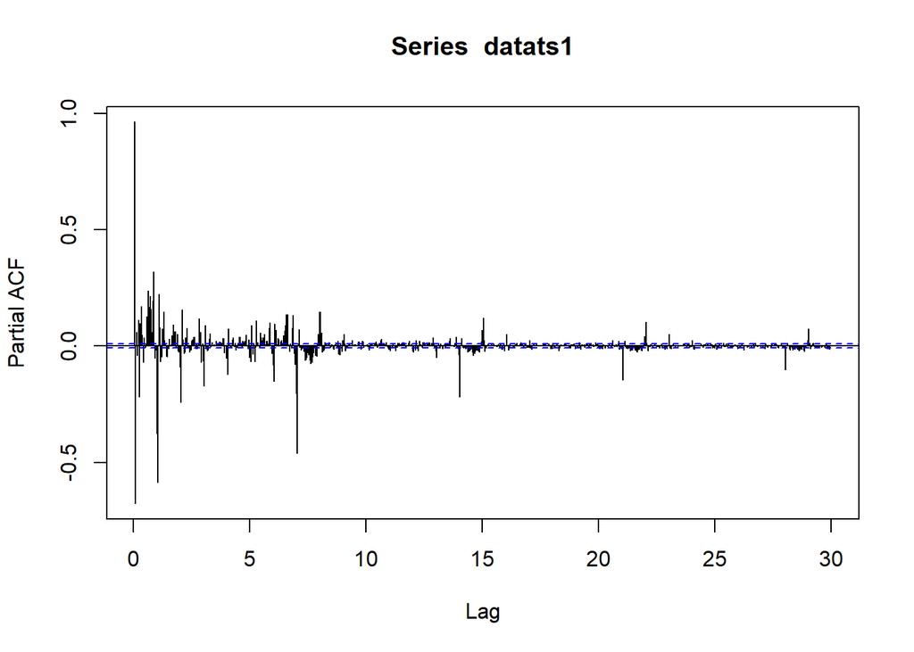

At lag 30 there is no significant autocorrelation compared to weekly seasonality. so there is no monthly seasonality.

## Decomposition

To build a time series model, we need to work with stationary series. To get stationary series we should eliminate the effect of trend and seasonality. Decomposition is a way to do this. Above, I tried different seasonalities.

### 1. Daily

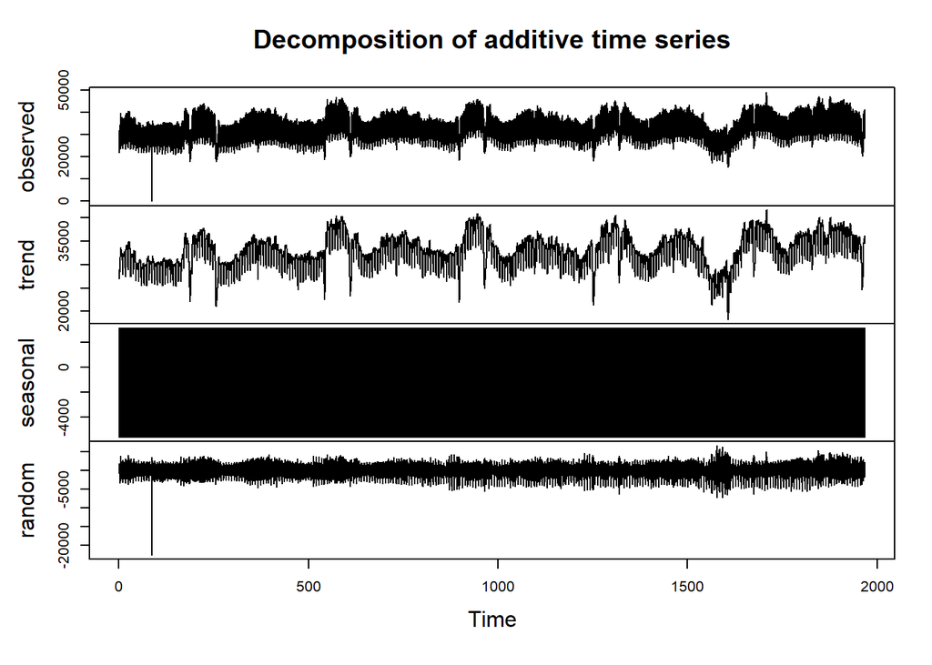

### 2. Weekly

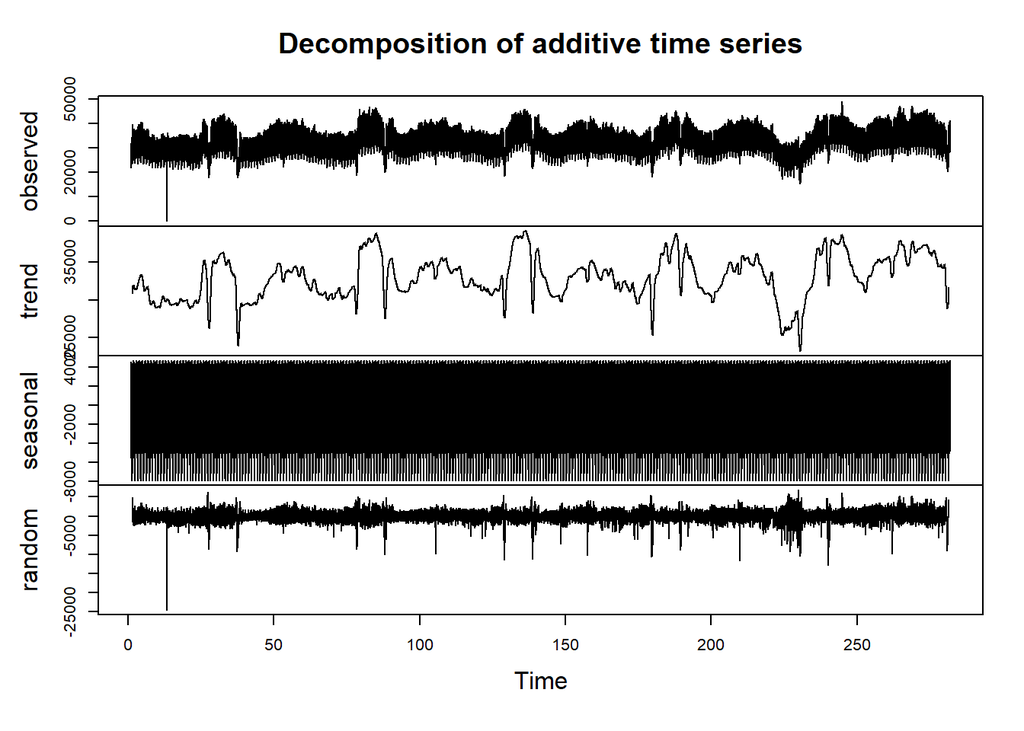

```
##
## #######################
## # KPSS Unit Root Test #
## #######################
##
## Test is of type: mu with 18 lags.
##
## Value of test-statistic is: 0.0042
##
## Critical value for a significance level of:
##                 10pct  5pct 2.5pct  1pct
## critical values 0.347 0.463  0.574 0.739
```

Test value is smaller than any critical value we can not reject the null hypothesis that is time series is stationary.

### 3. Monthly

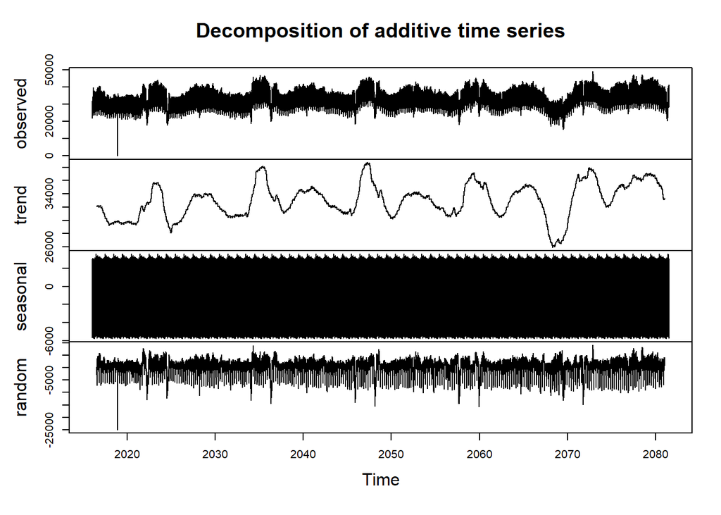

```
##
## #######################
## # KPSS Unit Root Test #
## #######################
##
## Test is of type: mu with 18 lags.
##
## Value of test-statistic is: 0.0074
##
## Critical value for a significance level of:
##                 10pct  5pct 2.5pct  1pct
## critical values 0.347 0.463  0.574 0.739
```

Test statistic is grater than weekly seasonality.

### 4. Monthly and Weekly

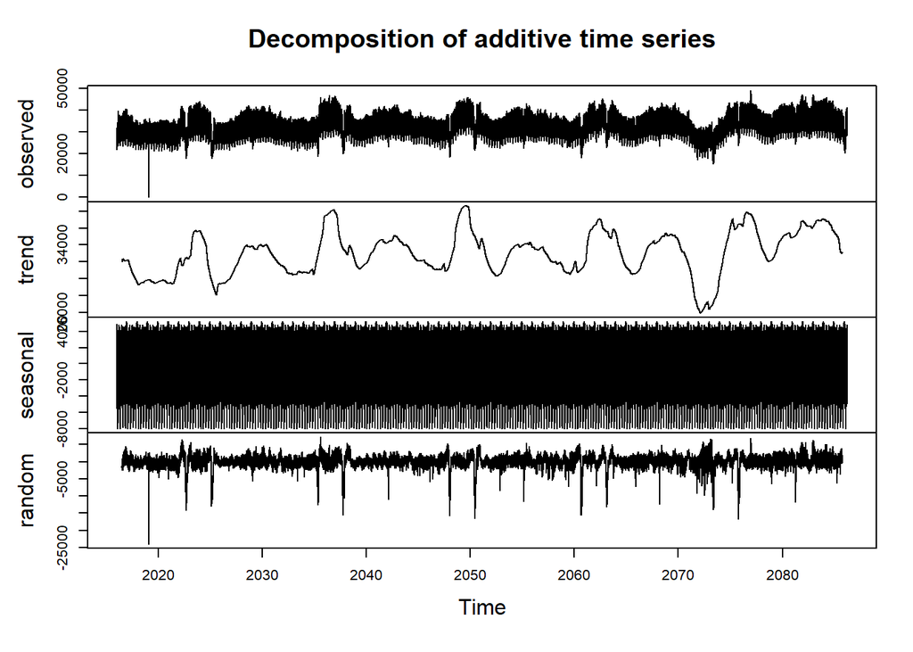

```
##
## #######################
## # KPSS Unit Root Test #
## #######################
##
## Test is of type: mu with 18 lags.
##
## Value of test-statistic is: 0.0152
##
## Critical value for a significance level of:
##                 10pct  5pct 2.5pct  1pct
## critical values 0.347 0.463  0.574 0.739
```

Again, test value is greater than weekly seasonality. So, I will move into with weekly seasonality.

## AR Models

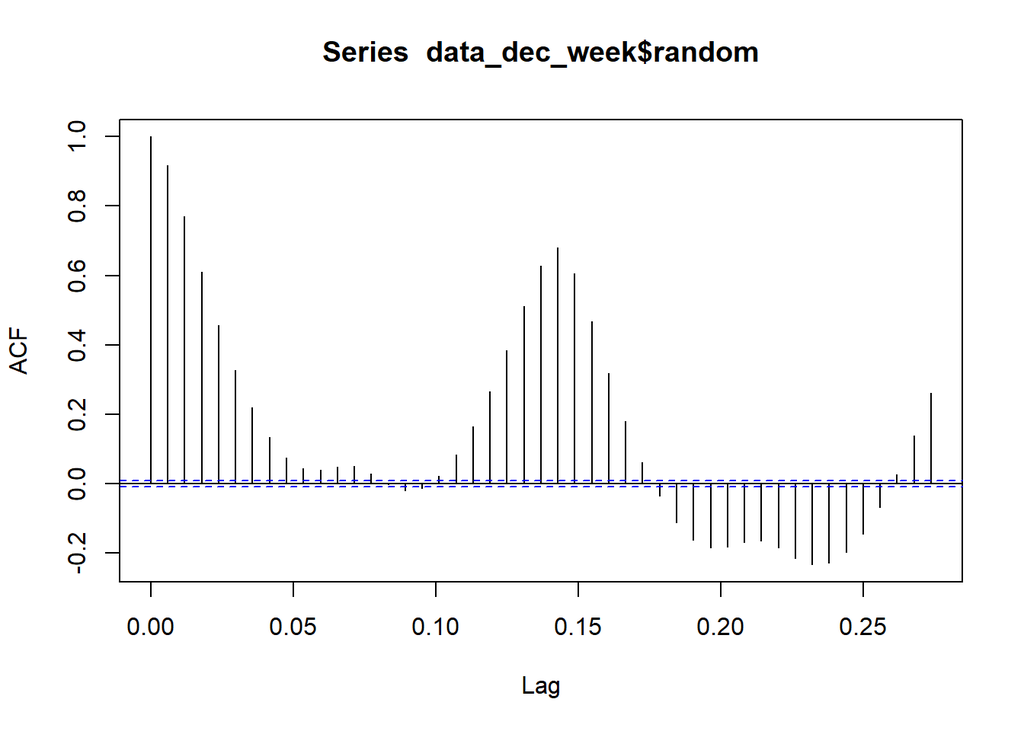

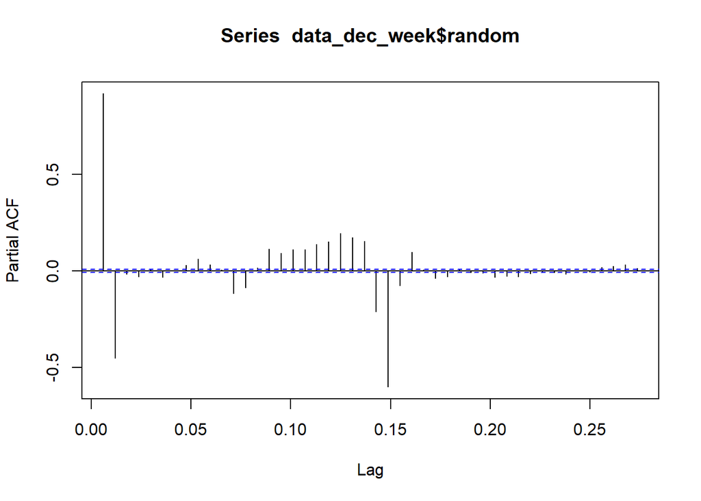

We have a sinusodial acf plot and there is spike at lag 2. This pattern occurs at Autoregressive Models. I will start trying values of lag p with 2.

### AR Model 1 (2,0,0)

```
##
## Call:
## arima(x = random, order = c(2, 0, 0))
##
## Coefficients:
##          ar1      ar2  intercept
##       1.3324  -0.4521    -1.0783
## s.e.  0.0041   0.0041    20.2591
##
## sigma^2 estimated as 276455:  log likelihood = -361449,  aic = 722906
```

### AR Model 2 (3,0,0)

```
##
## Call:
## arima(x = random, order = c(3, 0, 0))
##
## Coefficients:
##          ar1      ar2      ar3  intercept
##       1.3254  -0.4314  -0.0155    -1.0787
## s.e.  0.0046   0.0074   0.0046    19.9511
##
## sigma^2 estimated as 276389:  log likelihood = -361443.4,  aic = 722896.7
```

AIC value improved slightly. For the sake of simplicity I’ll continue with (2,0,0) model.

## MA Models

### MA Model 1 (0,0,1)

```
##
## Call:
## arima(x = random, order = c(0, 0, 1))
##
## Coefficients:
##          ma1  intercept
##       0.8539    -1.0796
## s.e.  0.0017     7.5591
##
## sigma^2 estimated as 782071:  log likelihood = -385906.9,  aic = 771819.8
```

We don’t have better AIC value than AR models.

### MA Model 2 (0,0,2)

```
##
## Call:
## arima(x = random, order = c(0, 0, 2))
##
## Coefficients:
##          ma1     ma2  intercept
##       1.2026  0.6142    -1.0790
## s.e.  0.0037  0.0029     8.8633
##
## sigma^2 estimated as 465785:  log likelihood = -373718.6,  aic = 747445.1
```

AIC value is improved.

```
##
## Call:
## arima(x = random, order = c(0, 0, 4))
##
## Coefficients:
##          ma1     ma2     ma3     ma4  intercept
##       1.3190  1.1665  0.7768  0.3124    -1.0784
## s.e.  0.0049  0.0066  0.0050  0.0041    11.8271
##
## sigma^2 estimated as 314484:  log likelihood = -364480.3,  aic = 728972.5
```

Still we dont have a better model.

## ARMA Models

### ARMA Model (2,0,3)

```
##
## Call:
## arima(x = random, order = c(2, 0, 3))
##
## Coefficients:
##          ar1      ar2      ma1      ma2     ma3  intercept
##       1.4279  -0.5363  -0.1023  -0.0472  0.0151    -0.7180
## s.e.  0.0252   0.0206   0.0257   0.0139  0.0076    19.3474
##
## sigma^2 estimated as 276108:  log likelihood = -361419.4,  aic = 722852.8
```

Which is a better than (2,0,0) AR model. However, AIC values are not significantly different.

## Fitted and Actual Values for Random Term

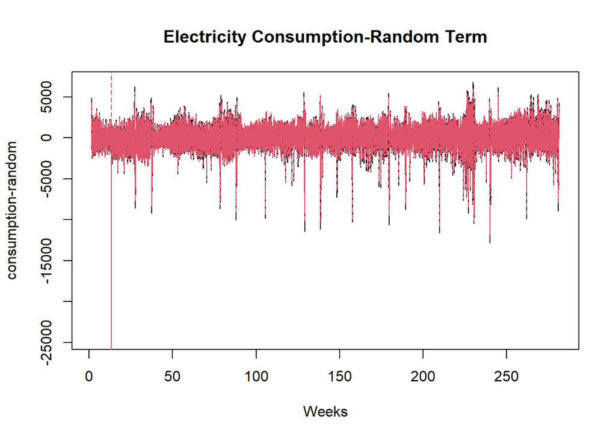

Averall fitted random values are close to actual random values.

## Fitted and actual Values for Electricity Consumption

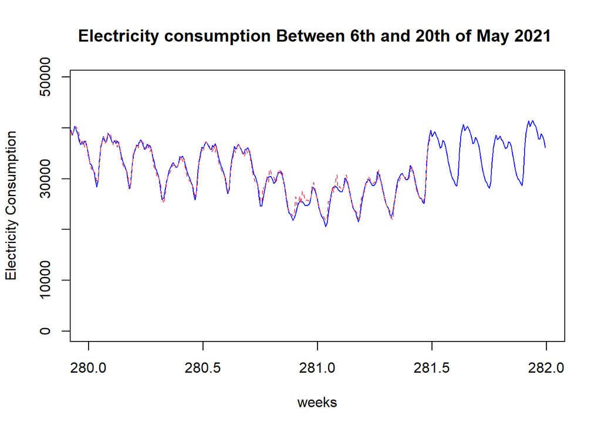

Like random values, trend an seasonality added values seem close.